# Sprawozdanie 4

Andrzej Miczek, Jakub Laszczyk

2023-10-27

# **1.Wykorzystanie lasów losowych do predykcji wartości zmiennej wynikowej.**

**Wczytanie bibliotek**

```r
library(ranger)
library(randomForest)
library(caret)
library(ggplot2)
```

**Wczytanie danych**

```r
dane <- read.csv("Heart2.csv", sep=";")
dane <-na.omit(dane)
```

**Podział danych**

```r
str(dane)
```

```
## 'data.frame':    818 obs. of  16 variables:
##  $ Age             : int  40 49 37 48 54 39 45 54 48 37 ...
##  $ Sex             : int  1 0 1 0 1 1 0 1 0 0 ...
##  $ RestingBP       : int  140 160 130 138 150 120 130 110 120 130 ...
##  $ Cholesterol     : int  289 180 283 214 195 339 237 208 284 211 ...
##  $ FastingBS       : int  0 0 0 0 0 0 0 0 0 0 ...
##  $ MaxHR           : int  172 156 98 108 122 170 170 142 120 142 ...
##  $ ExerciseAngina  : int  1 1 1 0 1 1 1 1 1 1 ...
##  $ Oldpeak         : num  0 1 0 1.5 0 0 0 0 0 0 ...
##  $ ChestPainTypeASY: int  0 0 0 1 0 0 0 0 0 0 ...
##  $ ChestPainTypeATA: int  1 0 1 0 0 0 1 1 1 0 ...
##  $ ChestPainTypeNAP: int  0 1 0 0 1 1 0 0 0 1 ...
##  $ RestingECGLVH   : int  0 0 0 0 0 0 0 0 0 0 ...
##  $ RestingECGNormal: int  1 1 0 1 1 1 1 1 1 1 ...
##  $ STSlopeDown     : int  0 0 0 0 0 0 0 0 0 0 ...
##  $ STSlopeFlat     : int  0 1 0 1 0 0 0 0 0 0 ...
##  $ heartDisease    : int  0 1 0 1 0 0 0 0 0 0 ...
```

```r
dane$heartDisease <- as.factor(dane$heartDisease)
set.seed(123)
ind <- sample(2, nrow(dane), replace = TRUE, prob = c(0.7, 0.3))
train_set <- dane[ind==1,]
test_set <- dane[ind==2,]
```

**Budowa random forest**

**Budowa modelu z domyślnymi wartosciami parametrów**

```r
#podstawowy model
model <- ranger(heartDisease ~ .,
                       data = train_set
                )

#predykcja i confusion matrix - train data
p1 <- predict(model, train_set)
confusionMatrix(p1$predictions, train_set$heartDisease)
```

```
## Confusion Matrix and Statistics
##
##           Reference
## Prediction   0   1
##          0 290   0
##          1   2 284
##
##                Accuracy : 0.9965
##                  95% CI : (0.9875, 0.9996)
##     No Information Rate : 0.5069
##     P-Value [Acc > NIR] : <2e-16
##
##                   Kappa : 0.9931
##
##  Mcnemar's Test P-Value : 0.4795
##
##             Sensitivity : 0.9932
##             Specificity : 1.0000
##          Pos Pred Value : 1.0000
##          Neg Pred Value : 0.9930
##              Prevalence : 0.5069
##          Detection Rate : 0.5035
##    Detection Prevalence : 0.5035
##       Balanced Accuracy : 0.9966
##
##        'Positive' Class : 0
##
```

```r
# predykcja i confusion matrix  - test data
p2 <- predict(model, test_set)
confusionMatrix(p2$predictions, test_set$heartDisease)
```

```
## Confusion Matrix and Statistics
##
##           Reference
## Prediction   0   1
##          0 100  16
##          1  18 108
##
##                Accuracy : 0.8595
##                  95% CI : (0.8092, 0.9007)
##     No Information Rate : 0.5124
##     P-Value [Acc > NIR] : <2e-16
##
##                   Kappa : 0.7187
##
##  Mcnemar's Test P-Value : 0.8638
##
##             Sensitivity : 0.8475
##             Specificity : 0.8710
##          Pos Pred Value : 0.8621
##          Neg Pred Value : 0.8571
##              Prevalence : 0.4876
##          Detection Rate : 0.4132
##    Detection Prevalence : 0.4793
##       Balanced Accuracy : 0.8592
##
##        'Positive' Class : 0
##
```

**Wybór optymalnej liczby drzew**

Jako pierwszy z parametrów została sprawdzona liczba drzew w lesie. Użyto do tego funkcji ranger oraz pętli sprawdzającej jak zachowuje się błąd prognozowania w zależności od różnych wartości num.trees. Sprawdzone zostały wartości liczby drzew z zakresu od 50 do 1000. Wartość mtry ustawiono jako 4(pierwaistek z liczby zmiennych), a kryterium podziału stanowił indeks Giniego. Następnie został wygenerowany wykres przedstawiający wyniki działania pętli.

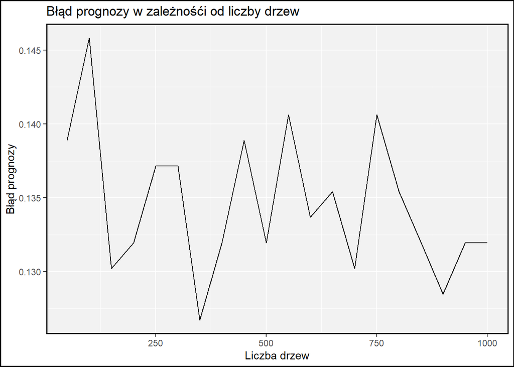

```r
#wybor num.trees
num.trees <- seq(50, 1000, by = 50)
oob.error <- vector("numeric", length(num.trees))

#mtry ustawiane jako pierwiastek z ilosci zmiennych
# Iterujemy przez różne liczby drzew
for (i in seq_along(num.trees)) {
  model <- ranger(heartDisease ~ .,
                  data = train_set,
                  num.trees = num.trees[i],
                  mtry = 4,
                  importance = 'impurity')
  oob.error[i] <- model$prediction.error
}

# Wizualizujemy wyniki
df <- data.frame(NumTrees = num.trees, OOBE = oob.error)
ggplot(df, aes(x = NumTrees, y = OOBE)) +
  geom_line() +
  labs(title = "Błąd prognozy w zależnośći od liczby drzew", x = "Liczba drzew", y = "Błąd prognozy")+
  theme(panel.border = element_rect(color = 'black',fill = NA,size = 1),
        panel.background = element_rect(fill='gray95'),
        plot.background = element_rect(color = 'black', size = 1)
        )
```

```r
min.error.index <- which.min(oob.error)
best.num.trees <- num.trees[min.error.index]
```

Kolejnymi parametrami które należało dopasować były mtry oraz max.depth. W tym celu została utworzona siatka zmiennych zawierające wszystkie kombinacje mtry z zakresu od 1 do 10 oraz max.depth z zakresu od 1 do 15. Sprawdzenie wartości parametrów przebiegało analogicznie jak w przypadku liczby drzew. Wartość num.trees została ustawiona na najlepszą wartość wyznaczoną w poprzednim kroku.

```r
# Stworzenie siatki parametrów do przetestowania
tune_grid <- expand.grid(max.depth = seq(1, 15, by = 1),
                         mtry.size = seq(1, 10, by = 1))

# Iteracja po siatce parametrów
for(i in 1:nrow(tune_grid)){
  max_depth_value <- tune_grid$max.depth[i]
  mtry_value <- tune_grid$mtry.size[i]

  model <- ranger(heartDisease ~ .,
                  data = train_set,
                  num.trees = best.num.trees,
                  mtry = mtry_value,
                  max.depth = max_depth_value,
                  importance = 'impurity')
  oob.error[i] <- model$prediction.error
}

min.error.index <- which.min(oob.error)
best_params <- tune_grid[min.error.index,]
```

Ostatnim etapem było zbudowanie lasu losowego za pomocą wybranych wcześniej parametrów, oraz ocena modelu.

```r
set.seed(123)
#finalny model i predykcja
model <- ranger(heartDisease ~ .,
                data = train_set,
                num.trees = best.num.trees,
                mtry = best_params$mtry.size,
                max.depth = best_params$max.depth,
                importance = 'impurity')


print(model)
```

```
## Ranger result
##
## Call:
##  ranger(heartDisease ~ ., data = train_set, num.trees = best.num.trees,      mtry = best_params$mtry.size, max.depth = best_params$max.depth,      importance = "impurity")
##
## Type:                             Classification
## Number of trees:                  350
## Sample size:                      576
## Number of independent variables:  15
## Mtry:                             4
## Target node size:                 1
## Variable importance mode:         impurity
## Splitrule:                        gini
## OOB prediction error:             13.19 %
```

```r
attributes(model)
```

```
## $names
##  [1] "predictions"               "num.trees"
##  [3] "num.independent.variables" "mtry"
##  [5] "min.node.size"             "variable.importance"
##  [7] "prediction.error"          "forest"
##  [9] "confusion.matrix"          "splitrule"
## [11] "treetype"                  "call"
## [13] "importance.mode"           "num.samples"
## [15] "replace"
##
## $class
## [1] "ranger"
```

```r
#predykcja i confusion matrix - train data
p3 <- predict(model, train_set)
confusionMatrix(p3$predictions, train_set$heartDisease)
```

```
## Confusion Matrix and Statistics
##
##           Reference
## Prediction   0   1
##          0 292   0
##          1   0 284
##
##                Accuracy : 1
##                  95% CI : (0.9936, 1)
##     No Information Rate : 0.5069
##     P-Value [Acc > NIR] : < 2.2e-16
##
##                   Kappa : 1
##
##  Mcnemar's Test P-Value : NA
##
##             Sensitivity : 1.0000
##             Specificity : 1.0000
##          Pos Pred Value : 1.0000
##          Neg Pred Value : 1.0000
##              Prevalence : 0.5069
##          Detection Rate : 0.5069
##    Detection Prevalence : 0.5069
##       Balanced Accuracy : 1.0000
##
##        'Positive' Class : 0
##
```

```r
# predykcja i confusion matrix  - test data
p4 <- predict(model, test_set)
confusionMatrix(p4$predictions, test_set$heartDisease)
```

```
## Confusion Matrix and Statistics
##
##           Reference
## Prediction   0   1
##          0 101  18
##          1  17 106
##
##                Accuracy : 0.8554
##                  95% CI : (0.8046, 0.8971)
##     No Information Rate : 0.5124
##     P-Value [Acc > NIR] : <2e-16
##
##                   Kappa : 0.7106
##
##  Mcnemar's Test P-Value : 1
##
##             Sensitivity : 0.8559
##             Specificity : 0.8548
##          Pos Pred Value : 0.8487
##          Neg Pred Value : 0.8618
##              Prevalence : 0.4876
##          Detection Rate : 0.4174
##    Detection Prevalence : 0.4917
##       Balanced Accuracy : 0.8554
##
##        'Positive' Class : 0
##
```

Ponieważ w algorytmie random forest wystepuje element losowości i nie zawsze zwracane wyniki są takie same została zastosowana petla w ktorej model został utworzony 10 razy, a wynikiem działania tej petli jest średnia dokładnosć z tych 10 modeli.

```r
num_iterations <- 10  # Liczba iteracji w pętli
mean_accuracy <- 0

for (i in 1:num_iterations) {
  # Trenowanie modelu Random Forest
  model <- ranger(heartDisease ~ .,
                  data = train_set,
                  num.trees = best.num.trees,
                  mtry = best_params$mtry.size,
                  max.depth = best_params$max.depth,
                  importance = 'impurity')

  # Przewidywanie na danych testowych
  przewidywania <- predict(model, data = test_set)$predictions

  # Obliczanie accuracy dla aktualnej iteracji
  accuracy <- sum(przewidywania == test_set$heartDisease) / length(przewidywania)

  # Dodawanie accuracy do sumy
  mean_accuracy <- mean_accuracy + accuracy
}

# Obliczanie średniej wartości accuracy
mean_accuracy <- mean_accuracy / num_iterations

# Wyświetlanie wyniku
cat("Mean accuracy:", mean_accuracy, "\n")
```

```
## Mean accuracy: 0.8628099
```

**Podsumowanie wyników:**

Najlepsza średnia dokładność na zbiorze testowym wynosiła **0.8628099** dla parametrów:

- num.tree = 350
- mtry = 4
- max.depth = 13

To oznacza, że model osiągnął średnią dokładność na zbiorze testowym wynoszącą około 86.28% przy użyciu tych konkretnych parametrów. Wynik ten może być użyteczny do oceny jakości modelu i porównywania go z innymi modelami lub zestawami parametrów.

# **2. Zastosowanie boostingu do predykcji wartości zmiennej wynikowej.**

Algorytm XGBoost (ang. Extreme Gradient boosting). Jest to zmodyfikowany algorytm wzmacniania gradientu, który został opracowany przez Tianqi Chena, i od tego czasu wygrywał liczne nagrody w konkursach organizowanych przez platformę Kaggle. W algorytm XGBoost w porównaniu do tradycyjnych metod wzmacniania gradientu wprowadzono miedzy innymi składnik regularyzacji, który odpowiada za kontrole złożoności modelu oraz redukcje wariancji stosując system kar nakładany na model za zbyt duża liczbę obserwacji w segmencie.

**Opis parametrów użytych w modelu XGBoost:**

- Nrounds – określa liczbę rund uczenia, w każdej rundzie tworzony jest nowy model bazowy.
- Eta – jest to współczynnik odpowiedzialny za korekty wagi w kolejnych modelach. Niska wartość oznacza mniejsze korekty co może być pomocne w przypadku problemu przeuczenia jednak wydłuża to proces uczenia modelu.
- Max.depth – Odpowiada za głębokość każdego drzewa.
- Subsample – Kontroluje liczbę obserwacji jakie są przekazywane do każdego drzewa. Mniejsza wartość oznacza większą losowość w doborze obserwacji.
- Colsample_bytree – określa jaka liczba zmiennych będzie przekazywana do każdego drzewa, tak samo jak w przypadku subsample mniejsza wartość od 1 oznacza większą losowość.
- Min.child.weight – jeśli suma wag „dzieci” jest mniejsza niż ten parametr to węzeł nie jest tworzony.

**Wczytanie bibliotek**

```r
library(xgboost)
library(Matrix)
library(caret)
library(mlr)
library(pROC)
```

**Wczytanie danych**

```r
danexboost <- read.csv("Heart2.csv", sep=";")
danexboost$heartDisease  <- as.numeric(danexboost$heartDisease)
```

**Podział danych**

```r
set.seed(123)
ind <- sample(2, nrow(danexboost), replace = TRUE, prob = c(0.7, 0.3))
train_set <- danexboost[ind==1,]
test_set <- danexboost[ind==2,]
```

**Stworzenie odpowiednich ramek danych**

```r
xgtrain <- xgb.DMatrix(data = as.matrix(train_set[, -length(test_set)]), label = train_set[,length(test_set)])
xgtest <- xgb.DMatrix(data = as.matrix(test_set[, -length(test_set)]), label = test_set[,length(test_set)])
```

**Budowa podstawowego modelu**

```r
# Parameters
xgb_params <- list("objective" = "binary:logistic",
                   "eval_metric" = "logloss"
                   )
watchlist <- list(train = xgtrain, test = xgtest)

xg_model <- xgb.train(params = xgb_params,
                      data = xgtrain,
                      booster = "gbtree",
                      nrounds = 500,
                      watchlist = watchlist,
                      eta = 0.1,
                      max.depth =6,
                      gamma = 0,
                      subsample = 0.8,
                      colsample_bytree = 1,
                      #missing = NA,
                      verbose = 2,
                      set.seed(123))
```

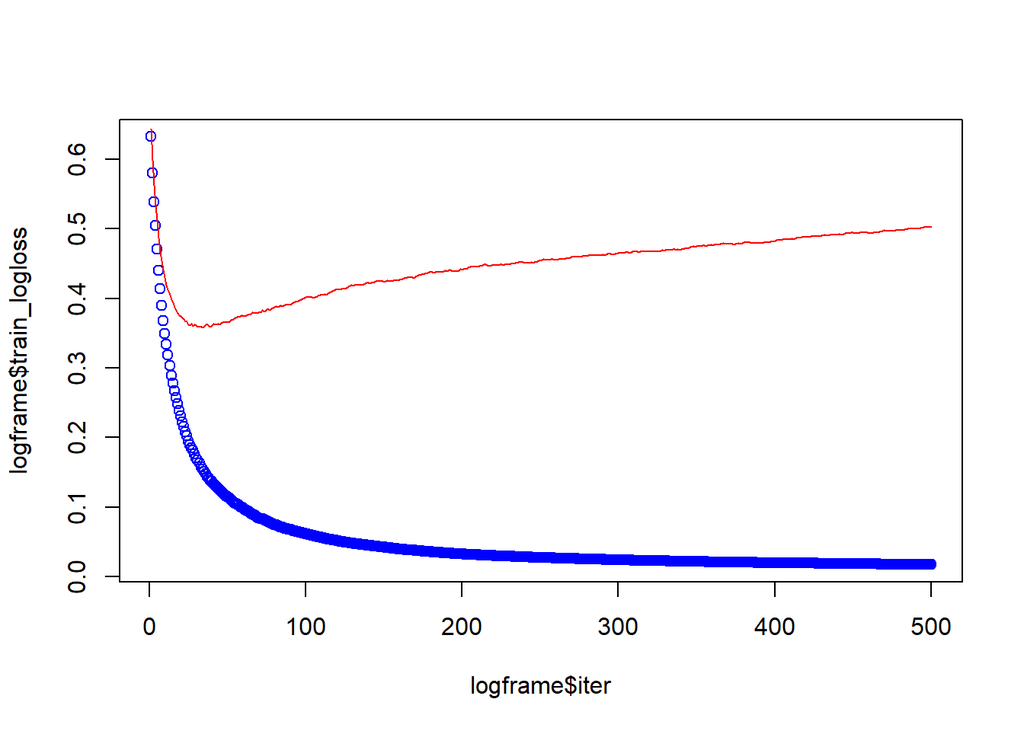

```r
logframe <- data.frame(xg_model$evaluation_log)
plot(logframe$iter, logframe$train_logloss, col = 'blue')
lines(logframe$iter, logframe$test_logloss, col = 'red')
```

```r
min(logframe$test_logloss)
```

```
## [1] 0.3579462
```

```r
logframe[logframe$test_logloss == min(logframe$test_logloss),]
```

```
##    iter train_logloss test_logloss
## 34   34     0.1541295    0.3579462
```

W celu wyznaczenia optymalnej wartości nround dla ustalonego poziomu eta za pomocą funkcji xgb.cv została przeprowadzona walidacja krzyżowa.

```r
params <- list(booster = "gbtree", objective = "binary:logistic", eta=0.1,
               gamma=0, max_depth=6, min_child_weight=1, subsample=0.8, colsample_bytree=1)

xgbcv <- xgb.cv( params = params, data = xgtrain, nrounds = 150, nfold = 5,
                 showsd = T, stratified = T, print_every_n = 10, early_stop_round = 20, maximize = F)
xgbcv$evaluation_log[xgbcv$evaluation_log$test_logloss_mean==min(xgbcv$evaluation_log$test_logloss_mean),]
```

```
##    iter train_logloss_mean train_logloss_std test_logloss_mean test_logloss_std
## 1:   44          0.1250382       0.005346185         0.3392267       0.06361763
```

Następnie została przeprowadzona weryfikacja podstawowego modelu na danych testowych oraz treningowych.

```r
 # predykcja i confusion matrix - train data
preds <- predict(xg_model, xgtrain)
preds <- ifelse(preds > 0.5, 1, 0)
preds <- as.factor(preds)
x <- as.factor(train_set[,length(train_set)])
# Ocena modelu
table(pred = preds, true = train_set[,length(train_set)])
```

```
##     true
## pred   0   1
##    0 292   0
##    1   0 284
```

```r
confusionMatrix(preds,x)
```

```
## Confusion Matrix and Statistics
##
##           Reference
## Prediction   0   1
##          0 292   0
##          1   0 284
##
##                Accuracy : 1
##                  95% CI : (0.9936, 1)
##     No Information Rate : 0.5069
##     P-Value [Acc > NIR] : < 2.2e-16
##
##                   Kappa : 1
##
##  Mcnemar's Test P-Value : NA
##
##             Sensitivity : 1.0000
##             Specificity : 1.0000
##          Pos Pred Value : 1.0000
##          Neg Pred Value : 1.0000
##              Prevalence : 0.5069
##          Detection Rate : 0.5069
##    Detection Prevalence : 0.5069
##       Balanced Accuracy : 1.0000
##
##        'Positive' Class : 0
##
```

```r
# predykcja i confusion matrix - test data
preds <- predict(xg_model, xgtest)
preds <- ifelse(preds > 0.5, 1, 0)
preds <- as.factor(preds)
x <- as.factor(test_set[,length(test_set)])
# Ocena modelu
table(pred = preds, true = test_set[,length(test_set)])
```

```
##     true
## pred   0   1
##    0 101  20
##    1  17 104
```

```r
confusionMatrix(preds,x)
```

```
## Confusion Matrix and Statistics
##
##           Reference
## Prediction   0   1
##          0 101  20
##          1  17 104
##
##                Accuracy : 0.8471
##                  95% CI : (0.7955, 0.89)
##     No Information Rate : 0.5124
##     P-Value [Acc > NIR] : <2e-16
##
##                   Kappa : 0.6942
##
##  Mcnemar's Test P-Value : 0.7423
##
##             Sensitivity : 0.8559
##             Specificity : 0.8387
##          Pos Pred Value : 0.8347
##          Neg Pred Value : 0.8595
##              Prevalence : 0.4876
##          Detection Rate : 0.4174
##    Detection Prevalence : 0.5000
##       Balanced Accuracy : 0.8473
##
##        'Positive' Class : 0
##
```

W kolejnym etapie przeprowadzono optymalizacje hiperparametrów z wykorzystaniem funkcji mlr().

```r
test_set$heartDisease <- as.factor(test_set$heartDisease)
train_set$heartDisease <- as.factor(train_set$heartDisease)
traintask <- makeClassifTask (data = train_set,target = "heartDisease")
testtask <- makeClassifTask (data = test_set,target = "heartDisease")

lrn <- makeLearner("classif.xgboost",predict.type = "response")
lrn$par.vals <- list( objective="binary:logistic", eval_metric="error", nrounds=40, eta=0.1,set.seed(123))


params <- makeParamSet(makeIntegerParam("max_depth",lower = 3L,upper = 10L),
                       makeNumericParam("min_child_weight",lower = 1L,upper = 10L),
                       makeNumericParam("subsample",lower = 0.5,upper = 1),
                       makeNumericParam("colsample_bytree",lower = 0.5,upper = 1))


resample <- makeResampleDesc("CV",stratify = T,iters=5L)
ctrl <- makeTuneControlRandom(maxit = 10L)
tune_params <- tuneParams(learner = lrn, task = traintask,
                     resampling = resample, measures = acc,
                     par.set = params ,control = ctrl,show.info = T)

tune_params$y
```

Ostatnim krokiem było przypisanie wyznaczonych wartości parametrów do modelu, a następnie obniżanie wartości eta wraz z jednoczesnym podnoszeniem wartości nrounds.

```r
#set hyperparameters
lrn_tune <- setHyperPars(lrn, par.vals = tune_params$x)
print(tune_params$x)
```

```
## $max_depth
## [1] 7
##
## $min_child_weight
## [1] 5.841058
##
## $subsample
## [1] 0.8135202
##
## $colsample_bytree
## [1] 0.6459869
```

```r
#train model
xgmodel <- mlr::train(learner=lrn_tune, task=traintask)
```

```r
#predykcja
xgpred <- predict(xgmodel,testtask)
confusionMatrix(xgpred$data$response,xgpred$data$truth)
```

```
## Confusion Matrix and Statistics
##
##           Reference
## Prediction   0   1
##          0 100  16
##          1  18 108
##
##                Accuracy : 0.8595
##                  95% CI : (0.8092, 0.9007)
##     No Information Rate : 0.5124
##     P-Value [Acc > NIR] : <2e-16
##
##                   Kappa : 0.7187
##
##  Mcnemar's Test P-Value : 0.8638
##
##             Sensitivity : 0.8475
##             Specificity : 0.8710
##          Pos Pred Value : 0.8621
##          Neg Pred Value : 0.8571
##              Prevalence : 0.4876
##          Detection Rate : 0.4132
##    Detection Prevalence : 0.4793
##       Balanced Accuracy : 0.8592
##
##        'Positive' Class : 0
##
```

```r
xg_model <- xgb.train(params = xgb_params,
                      data = xgtrain,
                      booster = "gbtree",
                      nrounds = 97,
                      watchlist = watchlist,
                      eta = 0.05,
                      max.depth =7,
                      gamma = 0,
                      subsample = 0.8135202,
                      colsample_bytree = 0.6459869,
                      min_child_weight = 5.841058,
                      verbose = 2,
                      set.seed(123))
```

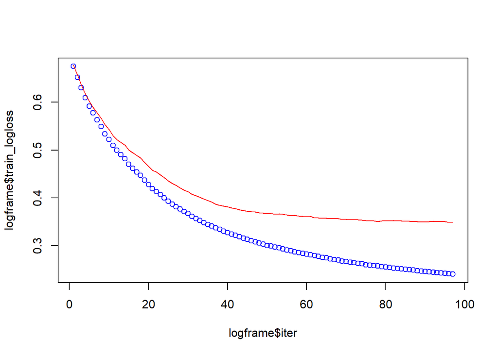

```r
logframe <- data.frame(xg_model$evaluation_log)
plot(logframe$iter, logframe$train_logloss, col = 'blue')
lines(logframe$iter, logframe$test_logloss, col = 'red')
```

```r
min(logframe$test_logloss)
```

```
## [1] 0.3488866
```

```r
logframe[logframe$test_logloss == min(logframe$test_logloss),]
```

```
##    iter train_logloss test_logloss
## 97   97     0.2403566    0.3488866
```

```r
 # predykcja i confusion matrix - train data
preds <- predict(xg_model, xgtrain)
preds <- ifelse(preds > 0.5, 1, 0)
preds <- as.factor(preds)
x <- as.factor(train_set[,length(train_set)])
# Ocena modelu
table(pred = preds, true = train_set[,length(train_set)])
```

```
##     true
## pred   0   1
##    0 269  25
##    1  23 259
```

```r
confusionMatrix(preds,x)
```

```
## Confusion Matrix and Statistics
##
##           Reference
## Prediction   0   1
##          0 269  25
##          1  23 259
##
##                Accuracy : 0.9167
##                  95% CI : (0.891, 0.9379)
##     No Information Rate : 0.5069
##     P-Value [Acc > NIR] : <2e-16
##
##                   Kappa : 0.8333
##
##  Mcnemar's Test P-Value : 0.8852
##
##             Sensitivity : 0.9212
##             Specificity : 0.9120
##          Pos Pred Value : 0.9150
##          Neg Pred Value : 0.9184
##              Prevalence : 0.5069
##          Detection Rate : 0.4670
##    Detection Prevalence : 0.5104
##       Balanced Accuracy : 0.9166
##
##        'Positive' Class : 0
##
```

```r
# predykcja i confusion matrix - test data
preds <- predict(xg_model, xgtest)
preds <- ifelse(preds > 0.5, 1, 0)
preds <- as.factor(preds)
x <- as.factor(test_set[,length(test_set)])
# Ocena modelu
table(pred = preds, true = test_set[,length(test_set)])
```

```
##     true
## pred   0   1
##    0 101  12
##    1  17 112
```

```r
confusionMatrix(preds,x)
```

```
## Confusion Matrix and Statistics
##
##           Reference
## Prediction   0   1
##          0 101  12
##          1  17 112
##
##                Accuracy : 0.8802
##                  95% CI : (0.8324, 0.9183)
##     No Information Rate : 0.5124
##     P-Value [Acc > NIR] : <2e-16
##
##                   Kappa : 0.7599
##
##  Mcnemar's Test P-Value : 0.4576
##
##             Sensitivity : 0.8559
##             Specificity : 0.9032
##          Pos Pred Value : 0.8938
##          Neg Pred Value : 0.8682
##              Prevalence : 0.4876
##          Detection Rate : 0.4174
##    Detection Prevalence : 0.4669
##       Balanced Accuracy : 0.8796
##
##        'Positive' Class : 0
##
```

**Najlepsze wyniki otrzymano dla parametrów:**

- nrounds = 97,
- eta = 0.05,
- max.depth = 7,
- gamma = 0,
- subsample = 0.8135202,
- colsample_bytree = 0.6459869,
- min_child_weight = 5.841058,

**Wynosiły one dla zbioru treningowego:**

*dokładność: 0.9167

*czułość:0.9212

*specyficzność: 0.9120

**dla zbioru testowego:**

*dokładność: 0.8802

*czułość:0.8559

*specyficzność: 0.9032

To oznacza, że najlepszy model został osiągnięty przy użyciu tych parametrów, a dokładność na zbiorze testowym wynosiła około 88.02%. Model ten wykazywał dobrą zdolność do generalizacji, zachowując wysoką czułość i specyficzność na zbiorze testowym, co sugeruje, że dobrze radził sobie zarówno z przypadkami pozytywnymi, jak i negatywnymi.

**Ocena ważności zmiennych**

```r
# Feature importance
imp <- xgb.importance(colnames(xgtrain), model = xg_model)
print(imp)
```

```
##              Feature        Gain       Cover   Frequency
##  1:      STSlopeFlat 0.246960708 0.132058942 0.082981716
##  2: ChestPainTypeASY 0.149418739 0.097639025 0.068917018
##  3:          Oldpeak 0.131450160 0.153437687 0.158931083
##  4:   ExerciseAngina 0.119267332 0.068585922 0.043600563
##  5:      Cholesterol 0.084554446 0.123514135 0.151898734
##  6:              Sex 0.077706544 0.079476697 0.054852321
##  7:            MaxHR 0.059677633 0.112079457 0.151898734
##  8:              Age 0.049240759 0.083595229 0.116736990
##  9:        FastingBS 0.043145295 0.061748167 0.046413502
## 10:        RestingBP 0.016680676 0.034270935 0.057665260
## 11:    RestingECGLVH 0.006545373 0.016177565 0.016877637
## 12: RestingECGNormal 0.006433766 0.016884767 0.028129395
## 13: ChestPainTypeATA 0.004538138 0.014686653 0.012658228
## 14:      STSlopeDown 0.002447043 0.001923509 0.001406470
## 15: ChestPainTypeNAP 0.001933388 0.003921310 0.007032349
```

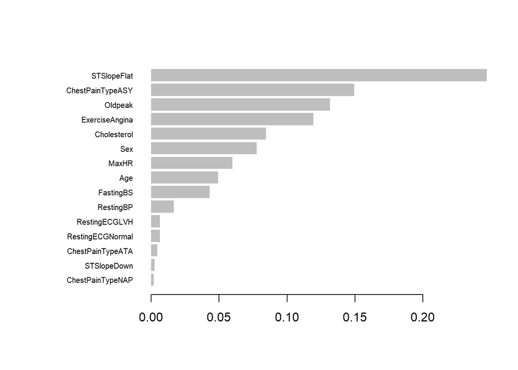

```r
xgb.plot.importance(imp)
```

Ważność zmiennych oceniana jest na podstawie tych trzech miar, które różnią się od siebie i mogą mieć różne interpretacje. Gain mierzy, ile dana zmienna przyczynia się do poprawy jakości modelu, Cover mierzy, jak wiele próbek jest pokrywanych przez daną zmienną, a Frequency mierzy, jak często zmienna występuje w zbiorze danych.

Na podstawie tych wyników można stwierdzić, że STSlopeFlat ma największą ważność, a ChestPainTypeNAP i STSlopeDown mają najmniejszą ważność. Ważność zmiennych można wykorzystać do selekcji zmiennych, optymalizacji modelu lub do lepszego zrozumienia wpływu zmiennych na wyniki modelu.

# **3. Porównanie wyników uzyskane za pomocą lasów losowych, boostingu, prostego drzewa decyzyjnego oraz baggingu.**

Porównując wyniki czterech różnych metod klasyfikacji:

**Lasów Losowych:**

- Dokładność: 0.8628099
- Czułość: 0.8559
- Specyficzność: 0.8548

**Boosting:**

- Dokładność: 0.8802
- Czułość: 0.8559
- Specyficzność: 0.9032

**Proste Drzewa Decyzyjne:**

- Dokładność: 0.8595
- Czułość: 0.8051
- Specyficzność: 0.9113

**Bagging:**

- Dokładność: 0.8843
- Czułość: 0.8305
- Specyficzność: 0.9355

**Wnioski na podstawie otrzymanych wyników:**

Metoda Bagging uzyskała najwyższą dokładność na zbiorze testowym spośród wszystkich badanych metod, wynoszącą 0.8843. Była również w stanie osiągnąć dobrą specyficzność (0.9355), co jest istotne w przypadku klasyfikacji problemów medycznych, gdzie false positives mogą mieć istotne konsekwencje.

Metoda Boosting również osiągnęła bardzo dobre wyniki, z dokładnością na poziomie 0.8802 i równocześnie wysoką czułością i specyficznością. Jest to silna metoda, która może być skuteczna w klasyfikacji problemów medycznych.

Las Losowy osiągnął nieco niższą dokładność niż Bagging i Boosting, ale wciąż był skuteczny. Jednak jego specyficzność była niższa, co może być istotne w niektórych kontekstach.

Proste Drzewa Decyzyjne osiągnęły nieco niższą dokładność niż pozostałe metody, a także miały niższą czułość. Jednak specyficzność była na dobrym poziomie.

**Wybór metody zależy od konkretnej sytuacji i wymagań problemu. Las Losowy i Bagging są silnymi kandydatami, jeśli zależy nam na stabilności i dobrej generalizacji. Boosting jest skuteczny, jeśli potrzebujemy bardzo wysokiej dokładności, ale może być bardziej złożony do dostrojenia. Proste Drzewa Decyzyjne są łatwe do interpretacji, ale mogą mieć niższą dokładność i być bardziej podatne na nadmierne dopasowanie. Ważne jest, aby dostosować wybór metody do konkretnej sytuacji i dokładnie ocenić jej wyniki na zbiorze testowym.**